# Quality Trimming - Anglerfish

Griffin Patel

2026-03-19

# Goals of this file

0. Load packages and prepare for fastq files.
1. Use raw fastq files and generate quality plots to assess quality of raw reads.
2. Evaluate whether primers are present in the sequences.
3. Filter and trim out primers, bad sequences and bases from the sequencing files.
4. Assess if filtering and trimming was adequate. If not, re-run with new parameters.
5. Write out fastq files with high quality sequences.
6. Evaluate the quality from the filter and trim step and whether it is adequate.

Output that we will create in this file:

1. Quality plots to assess pre- and post-quality trimming.
2. Written files that include the filtered and trimmed data. (Note that this will be written during the `filterAndTrim()` function.)

Why is it useful to set a seed?

1. *Reproducibility*:
   - If you’re using random number generation (e.g., bootstrapping, simulations, machine learning models), setting a seed ensures that you (and others) can get the same results every time you run the code.
2. *Debugging & Collaboration*:
   - If your analysis involves randomness (e.g., shuffling datasets, training ML models), setting a seed makes it easier to debug and compare results across different runs or machines.
   - Colleagues can run your code and get identical results, making scientific collaboration more reliable.
3. *Benchmarking & Model Comparisons*:
   - In machine learning, setting a seed ensures that models trained with random splits of data or initial weights are comparable across different trials.
   - If you don’t set a seed, each run might give slightly different performance metrics, making it harder to evaluate true differences between models.
4. *Avoiding Accidental Bias in Random Sampling*:
   - When selecting random subsets of data (e.g., cross-validation splits), setting a seed ensures that all experiments are based on the same random selection, reducing unwanted variability.

```r
# Any number can be chosen
set.seed(238428)
```

### Timing of Script

```r
# What time did we start running this script?
start_time <- Sys.time()
start_time
```

```
## [1] "2026-03-19 21:22:09 EDT"
```

# Load Libraries

```r
# Efficient package loading with pacman
pacman::p_load(tidyverse, dada2, patchwork, DT,
               devtools, Biostrings, ShortRead,
               install = FALSE)
```

# Prepare Raw fastq Files

```r
# Set the raw fastq path to the raw sequencing files
# Path to the fastq files
raw_fastqs_path <- "data/00_raw_gzipped_fastqs"
raw_fastqs_path
```

```
## [1] "data/00_raw_gzipped_fastqs"
```

```r
# What files are in this path? Intuition Check
head(list.files(raw_fastqs_path))
```

```
## [1] "SRR8438042_1.fastq.gz" "SRR8438042_2.fastq.gz" "SRR8438042.fastq.gz"
## [4] "SRR8438043_1.fastq.gz" "SRR8438043_2.fastq.gz" "SRR8438043.fastq.gz"
```

```r
# How many files are there?
length(list.files(raw_fastqs_path))
```

```
## [1] 348
```

```r
# Create vector of forward reads
forward_reads <- sort(list.files(raw_fastqs_path, pattern = "_1\\.fastq\\.gz$", full.names = TRUE))

# Create a vector of reverse reads
reverse_reads <- sort(list.files(raw_fastqs_path, pattern = "_2\\.fastq\\.gz$", full.names = TRUE))

# Intuition checks
stopifnot(length(reverse_reads) == length(forward_reads))

# Intuition check #2: Need to have equal number of forward and reverse files
stopifnot(length(reverse_reads) == length(forward_reads))

# Create sample names from forward reads
sample_names <- sub("_1\\.fastq\\.gz$", "", basename(forward_reads))

# Intuition Checks
head(sample_names)
```

```
## [1] "SRR8438042" "SRR8438043" "SRR8438044" "SRR8438045" "SRR8438046"
## [6] "SRR8438047"
```

```r
# Intuition check #3: Forward and reverse sample names should match
stopifnot(identical(sample_names, sub("_2\\.fastq\\.gz$", "", basename(reverse_reads))))
```

# Assess the raw read quality

```r
# Randomly select up to 12 samples to assess
stopifnot(length(reverse_reads) > 0)

random_samples <- sample(seq_along(reverse_reads),
                         size = min(12, length(reverse_reads)))
random_samples
```

```
##  [1]  59 104  45  49  80 103  92  40  68   8  43 108
```

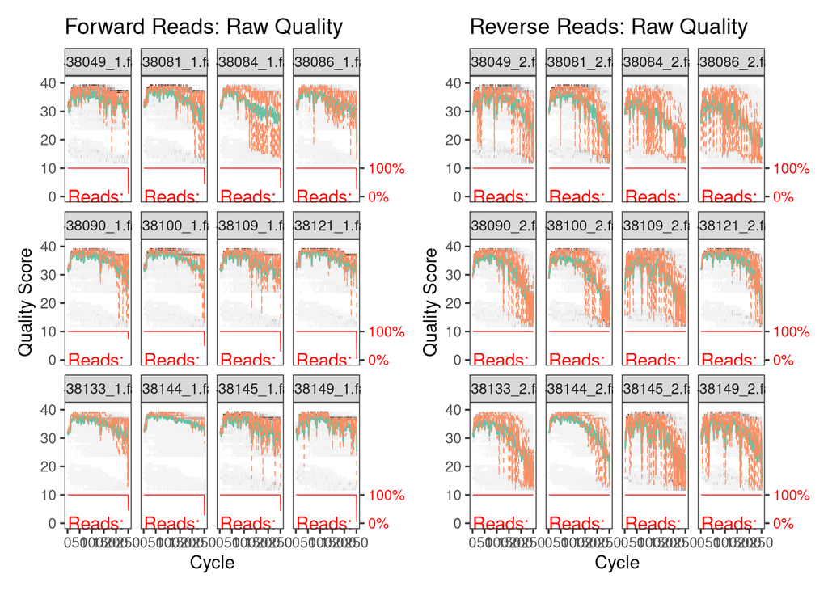

```r
# Plot forward read quality
forward_rawQual_plot12 <-
  plotQualityProfile(forward_reads[random_samples]) +
  labs(title = "Forward Reads: Raw Quality")
# Plot reverse read quality
reverse_rawQual_plot12 <-
  plotQualityProfile(reverse_reads[random_samples]) +
  labs(title = "Reverse Reads: Raw Quality")

# Plot both plots together
forward_rawQual_plot12 + reverse_rawQual_plot12
```

**REMEMBER:** If you have NextSeq data, your quality scores will be binned, instead of having the 40 integer phred scores. This is ok!

**Acceptable Phred Scores for ASVs with DADA2**

In DADA2, quality filtering is crucial for obtaining reliable biological sequences. Below are the acceptable **Phred score** thresholds for DADA2 preprocessing:

| **Q Score** | **Error Probability** | **DADA2 Interpretation** |
| --- | --- | --- |
| **40** | 0.0001 (1 in 10,000) | Very high-quality , dream come true |
| **≥30** | ≤ 0.001 (1 in 1,000) | Excellent quality, keep |
| **25-30** | ~0.003 - 0.01 | Can be acceptable, but more important to trim low-quality tails |
| **20-25** | ~0.01 - 0.03 | Lower quality, only acceptable if read length is absolutely critical |
| **<20** | > 0.01 (1 in 100) | Poor quality, remove |
| **<10** | >0.1 (1 in 10) | Very unreliable, absolutely remove |

Some summary take-aways:

- **30 is good** – Bases with Q30+ scores have a **99.9% accuracy rate**, making them highly reliable.
- **25-30 can be acceptable**, but trimming is preferred to remove low-quality tails.
- **20-25** should only be kept if read length is absolutely critical (*e.g.* to ensure forward & reverse read overlap)
- **<20 discarded** – Bases with Phred scores below 20 have an **error rate >1%** and should 100% be **trimmed from the dataset**.

Remember, every base counts when we assign ASVs, they are called **sequence variants** for a reason! And, we want to be sure.

## Prepare filtering and Trimming

```r
#Create vector of sample names
sample_names <- sapply(strsplit(basename(forward_reads), "_"), `[`, 1)

# Create a test of sample names
sample_names_R2 <- sapply(strsplit(basename(reverse_reads), "_"), `[`, 1)

# StopIfNot
stopifnot(sample_names == sample_names_R2)

#Test
head(sample_names)
```

```
## [1] "SRR8438042" "SRR8438043" "SRR8438044" "SRR8438045" "SRR8438046"
## [6] "SRR8438047"
```

```r
# Provide path for the filtered reads
filtered_fastqs_path <- "data/01_Quality_Trimming/filtered_fastqs"
filtered_fastqs_path
```

```
## [1] "data/01_Quality_Trimming/filtered_fastqs"
```

```r
# Create 2 vectors: filtered_forward_reads & filtered_reverse_reads
filtered_forward_reads <-
  file.path(filtered_fastqs_path, paste0(sample_names, "_R1_filtered.fastq.gz"))
filtered_reverse_reads <-
   file.path(filtered_fastqs_path, paste0(sample_names, "_R2_filtered.fastq.gz"))

#intuition check
length(filtered_forward_reads)
```

```
## [1] 117
```

```r
length(filtered_reverse_reads)
```

```
## [1] 117
```

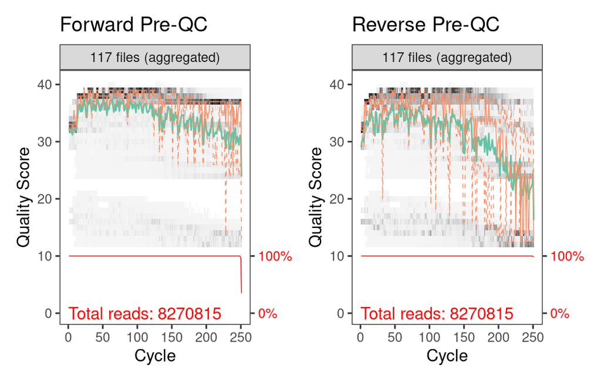

```r
# Aggregate all QC plots
# Forward reads
forward_preQC_plot <-
  plotQualityProfile(forward_reads, aggregate = TRUE) +
  labs(title = "Forward Pre-QC")

# reverse reads
reverse_preQC_plot <-
  plotQualityProfile(reverse_reads, aggregate = TRUE) +
  labs(title = "Reverse Pre-QC")

# Now, let's put the two plots together
preQC_aggregate_plot <-
  # Plot the forward and reverse together
  forward_preQC_plot + reverse_preQC_plot
# Show the plot
preQC_aggregate_plot
```

INTERPRETATION #1 of Pre-QC: Here, in this location of your analyses, please insert a description of the interpretation you draw regarding your plots. You must note anything important about the figure you’ve created about your data including any spikes in quality and also the general trend of the raw QC plots. An example is provided below.

My plots were generated with 2x250 bp sequencing on an Illumina MiSeq Sequencer, and show both the aggregated forward and reverse Pre-QC reads. There is a small drop in quality in the early bases, but none that are below 30, so there is no need to trim the front. Quality in both the forward and reverse sequences is stable and very high between 20 and 150 bp, and then steadily starts decreasing in quality from that point. The forward reads quality doesn’t begin dropping below 30 on average until around 220-225bp, while the reverse reads reach a sub-30 quality average much sooner, around the 175bp mark. There are also very brief spikes in low quality in the reverse reads earlier, but never to an unusable quality threshold. It appears that both forward and reverse reads do not require trimming at the beginning, but the forward reads should have their later read tail trimmed to 220bp, and reverse reads to 200bp. This still puts the quality into the more questionable 25-30 range, but because quality is high elsewhere, in the interests of preserving as much read length, it will be used. This drop in quality as the reads go on is to be expected with illumina sequencing, as the error rate increases with later cycles.

# 2. Evaluate Primer Search

> Does your dataset include primers?

Before we go ahead and filter and trim our reads, we need to confirm whether or not the raw seuqences include the primer sequences in them. Their presence depends on the type of libray prepration protocol that was used.

However, if the standard Illumina 2-step PCR library prep was used, **then primers will be included in the sequences and they will need to be trimmed out of the sequences later.**

Now, let’s check for those primers!

```r
# Search the sequences for primers to check if they are present
# Pull out the raw_fastq sequences from all of the raw sequencing files
raw_fastqs <- readFastq(dirPath = raw_fastqs_path)

# The above code makes a complex object. Let's only grab the DNA sequences
all_seqs <- sread(raw_fastqs)

f_primer <- "GTGYCAGCMGCCGCGGTAA"
r_primer <- "GGACTACNVGGGTWTCTAAT"

# Search the dataset
# Check the complement of the primers
Fprimer_complement <- complement(DNAString(f_primer))
Fprimer_revComplement <- reverseComplement(DNAString(f_primer))

Rprimer_complement <- complement(DNAString(r_primer))
Rprimer_revComplement <- reverseComplement(DNAString(r_primer))

############ POSITIVE CONTROLS OF CODE TO MAKE SURE IT WORKS ############

# Use one real sequence from this dataset as a test sequence
test_DNAseq <- all_seqs[[1]]

# Create a positive control pattern from a real read in this dataset
real_pos_pattern <- as.character(subseq(test_DNAseq, start = 20, width = 15))

# Positive control intuition check
pos_control <-
  vcountPattern(pattern = real_pos_pattern,
                subject = all_seqs,
                fixed = FALSE)

paste("Positive control is found in",
      round(mean(pos_control > 0) * 100, digits = 2),
      "% of sequences")
```

```
## [1] "Positive control is found in 36.03 % of sequences"
```

```r
# When there is a match, vmatchPattern can be used to locate the indices of the matches
test_pos_control <-
  vmatchPattern(pattern = real_pos_pattern,
                subject = all_seqs,
                fixed = FALSE)

# Take a look
head(test_pos_control)
```

```
## MIndex object of length 6
## [[1]]
## IRanges object with 1 range and 0 metadata columns:
##           start       end     width
##       <integer> <integer> <integer>
##   [1]        20        34        15
##
## [[2]]
## IRanges object with 0 ranges and 0 metadata columns:
##        start       end     width
##    <integer> <integer> <integer>
##
## [[3]]
## IRanges object with 0 ranges and 0 metadata columns:
##        start       end     width
##    <integer> <integer> <integer>
##
## ...
## <3 more elements>
```

```r
# Double check the degenerate nucleotides are ok within these functions, too
pos_degen_control <-
  vcountPattern(pattern = "GTGYC",
                subject = all_seqs,
                fixed = FALSE)

paste("Positive control with a degenerate base is found in",
      round(mean(pos_degen_control > 0) * 100, digits = 2),
      "% of sequences")
```

```
## [1] "Positive control with a degenerate base is found in 19.83 % of sequences"
```

```r
stopifnot(sum(pos_degen_control) > 0)
```

Now, let’s specifically test for the **forward** primers:

```r
############ FORWARD PRIMERS ############
# Now, let's search the sequences for the primers
# Search first for forward primer
Fprimer_vmatch <-
  vcountPattern(pattern = f_primer,
                subject = all_seqs,
                fixed = FALSE);
# Note:
paste("The forward primer is found in", round(sum(Fprimer_vmatch)/length(all_seqs) * 100, digits = 2),
      "% of sequences")
```

```
## [1] "The forward primer is found in 0 % of sequences"
```

```r
# Then double check with complement of forward primer
Fprimer_complement_vmatch <-
  vcountPattern(pattern = Fprimer_complement,
                subject = all_seqs,
                fixed = FALSE);
# Note:
paste("The complement of the forward primer is found in", round(sum(Fprimer_complement_vmatch)/length(all_seqs) * 100, digits = 2),
      "% of sequences")
```

```
## [1] "The complement of the forward primer is found in 0 % of sequences"
```

Great, now let’s specifically test for the **reverse** primers:

```r
############ REVERSE PRIMERS ############
# Now, let's search for the reverse primer
Rprimer_vmatch <-
  vcountPattern(pattern = r_primer,
                subject = all_seqs,
                fixed = FALSE);
paste("The reverse primer is found in", round(sum(Rprimer_vmatch)/length(all_seqs) * 100, digits = 2),
      "% of sequences")
```

```
## [1] "The reverse primer is found in 0 % of sequences"
```

```r
# Then double check with complement of forward primer
Rprimer_complement_vmatch <-
  vcountPattern(pattern = Rprimer_complement,
                subject = all_seqs,
                fixed = FALSE);
paste("The complement of reverse primer is found in", round(sum(Rprimer_complement_vmatch)/length(all_seqs) * 100, digits = 2),
      "% of sequences")
```

```
## [1] "The complement of reverse primer is found in 0 % of sequences"
```

INTERPRETATION #2 — Primer Evaluation: Based on the primer search results above, determine whether primer sequences are present in your dataset. Explain your conclusion and describe how the presence or absence of primers will influence the parameters used in the filterAndTrim() step.

My outputs of the forward and reverse primer searches were “The forward primer is found in 0 % of sequences + The complement of the forward primer is found in 0 % of sequences” and “The reverse primer is found in 0 % of sequences + The complement of the reverse primer is found in 0 % of sequences” respectively. This shows that the primers are not present in my data and will not need to be accounted for in my filter and trim step. My filterAndTrim() parameters will not be influenced by my primers.

# 3. Filter and Trim

## A. Prepare a placeholder for filtered reads

```r
# Create vector of sample names from the filenames
sample_names <- sapply(strsplit(basename(forward_reads), "_"), `[`,1)

# Intuition Check
head(sample_names)
```

```
## [1] "SRR8438042" "SRR8438043" "SRR8438044" "SRR8438045" "SRR8438046"
## [6] "SRR8438047"
```

```r
# Place filtered reads into filtered_fastqs_path
filtered_fastqs_path <- "data/01_Quality_Trimming/filtered_fastqs"

# Intuition Check
filtered_fastqs_path
```

```
## [1] "data/01_Quality_Trimming/filtered_fastqs"
```

```r
# create 2 vectors: filtered_forward_reads & filtered_reverse_reads
filtered_forward_reads <-
  file.path(filtered_fastqs_path, paste0(sample_names, "_R1_filtered.fastq.gz"))

# Intuition Check
length(filtered_forward_reads)
```

```
## [1] 117
```

```r
# reverse reads
filtered_reverse_reads <-
  file.path(filtered_fastqs_path, paste0(sample_names, "_R2_filtered.fastq.gz"))

# Intuition Check
head(filtered_reverse_reads)
```

```
## [1] "data/01_Quality_Trimming/filtered_fastqs/SRR8438042_R2_filtered.fastq.gz"
## [2] "data/01_Quality_Trimming/filtered_fastqs/SRR8438043_R2_filtered.fastq.gz"
## [3] "data/01_Quality_Trimming/filtered_fastqs/SRR8438044_R2_filtered.fastq.gz"
## [4] "data/01_Quality_Trimming/filtered_fastqs/SRR8438045_R2_filtered.fastq.gz"
## [5] "data/01_Quality_Trimming/filtered_fastqs/SRR8438046_R2_filtered.fastq.gz"
## [6] "data/01_Quality_Trimming/filtered_fastqs/SRR8438047_R2_filtered.fastq.gz"
```

## B. Actually Filter and Trim Reads

```r
# Assign and write out filtered fastq files
# Here, in this class dataset, the Kozich et al.(2013) AEM
      # Link to paper: https://doi.org/10.1128/AEM.01043-13
# Therefore, we do not need to trim the primers, because they were not sequenced
filtered_reads <-
  filterAndTrim(
    fwd = forward_reads, filt = filtered_forward_reads,
    rev = reverse_reads, filt.rev = filtered_reverse_reads,
    maxN = 0, maxEE = c(2,2),
    trimLeft = c(0,0),                  # no front trimming (matches your interpretation)
    truncLen = c(220, 200),             # matches your QC plots
    truncQ = 2, rm.phix = TRUE, compress = TRUE,
    multithread = 20
  )

##### Another example of a filterAndTrim Step
# This dataset is from sequences generated by Cornell Sequencing Facility using
# the typical Earth Microbiome protocol mentioned in their 16S SOP:
        # https://earthmicrobiome.org/protocols-and-standards/16s/
# Here, the library prep was the standard Illumina 2-step PCR preparation and following
# In this example, the primer sequences ARE in the sequences and must be trimmed using trimLeft
#
#filterAndTrim(forward_reads, filtered_forward_reads,
#              reverse_reads, filtered_reverse_reads,
#              truncLen = c(240,220), trimLeft = c(19,20),
#              maxN = 0, maxEE = c(1,1), truncQ = 2,
#              rm.phix = TRUE, compress = TRUE,
#              # Please set threads to be 8-10 (we want to respect others using the server!)
#              # Note that if TRUE, it will use ALL threads (making it hard for others to use the server)
#              # multithread = 10)
```

RATIONALE: Explain the reasoning behind the parameters you selected for the filterAndTrim() step. In your answer, reference relevant patterns from your FastQC or MultiQC reports (e.g., quality score drop-off, adapter/primer signal, read length distribution) that informed your trimming and filtering decisions. You may also cite guidance from the DADA2 workflow. Why were these parameter values appropriate for your dataset?

The choices for filtering and trimming were based on both the primer search results and the patterns seen in the quality plots. The primer search showed that primers were not present in the dataset, and quality was above Q30 for forward and reverse reads at the start, so there was no need to remove any bases from the start of the reads. The forward reads stayed high quality until about 220–225 bp, while the reverse reads started to drop off earlier, around 175–200 bp, and showed a more noticeable decline toward the end. Because of this, the forward reads were kept longer and only trimmed to 220 bp, while the reverse reads were trimmed to 200 bp to remove the lower-quality tail, while trying not to truncate the reads too much. Ideally, I would keep more on the reverse reads tail, but this was the best balance of quality and length. Additional filtering steps were used to remove any reads with ambiguous bases and to limit the number of expected sequencing errors, but these were kept at reasonable levels so that good reads weren’t unnecessarily thrown out. Overall, my choices removed the lower-quality portions of the reads and still kept a high number of sequences and enough read length for downstream analysis.

## C. Plot Filtered & Trimmed Read Quality of Subset of Samples

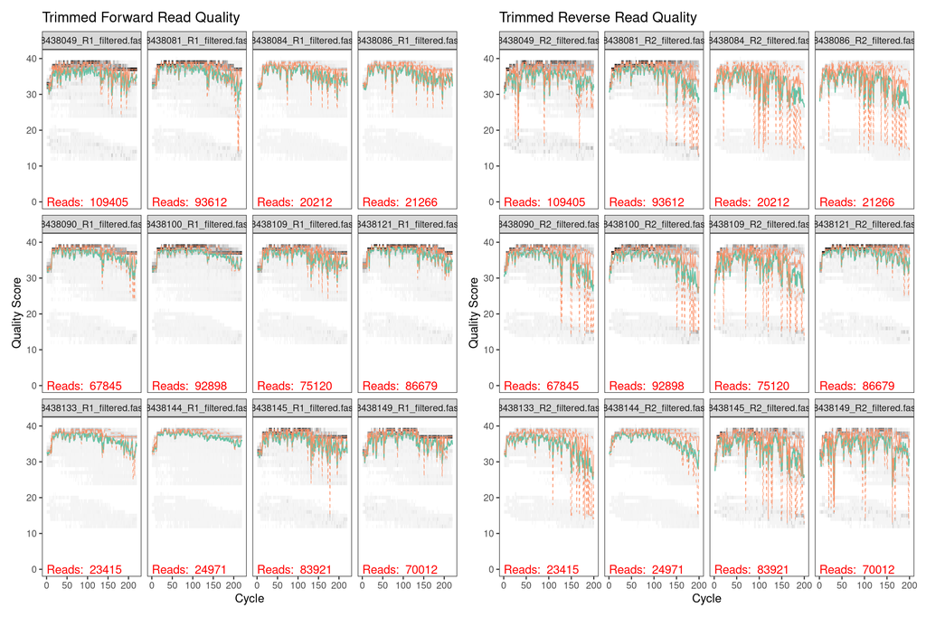

```r
# Plot the 12 random samples after QC
forward_filteredQual_plot_12 <-
  plotQualityProfile(filtered_forward_reads[random_samples]) +
  labs(title = "Trimmed Forward Read Quality")

reverse_filteredQual_plot_12 <-
  plotQualityProfile(filtered_reverse_reads[random_samples]) +
  labs(title = "Trimmed Reverse Read Quality")

# Put the two plots together
forward_filteredQual_plot_12 + reverse_filteredQual_plot_12
```

## D. Plot Aggregated Filtered & Trimmed Plots of All Samples

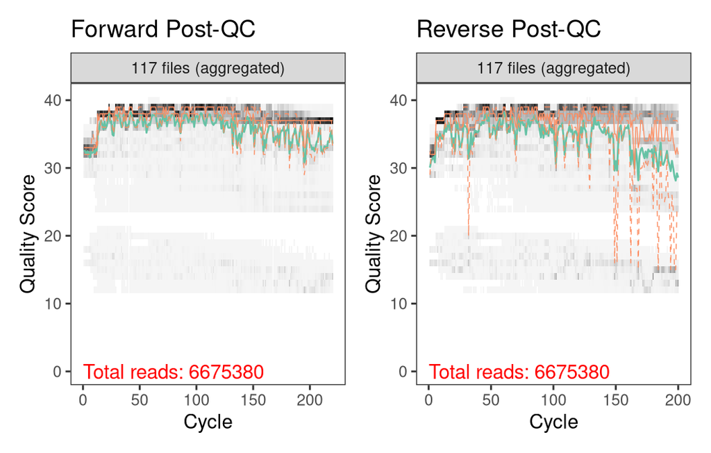

```r
# Aggregate all QC plots
# Forward reads
forward_postQC_plot <-
  plotQualityProfile(filtered_forward_reads, aggregate = TRUE) +
  labs(title = "Forward Post-QC")

# reverse reads
reverse_postQC_plot <-
  plotQualityProfile(filtered_reverse_reads, aggregate = TRUE) +
  labs(title = "Reverse Post-QC")

# Now, let's put the two plots together
postQC_aggregate_plot <-
  # Plot the forward and reverse together
  forward_postQC_plot + reverse_postQC_plot
# Show the plot
postQC_aggregate_plot
```

## E. Save Filtered Reads Data

```r
# SAVE DATA FIRST
save(filtered_reads, file = "data/01_Quality_Trimming/filtered_reads.RData")
```

# 4. Assess if filtering and trimming was adequate. If not, re-run with new parameters.

INTERPRETATION #3 of Post-QC: Here, in this location of your analyses, please insert a description of the interpretation you draw regarding your post filterAndTrim plots. Please note anything important about the figure you’ve created about your data generally speaking to your post-QC reads. What’s the general trend? In the next question, we will plot the pre- and post-QC togeter and compare them. The goal here is to evaluate the QC process. An example is provided below.

The post-QC plots show that overall read quality is higher and more consistent after filtering and trimming. In the forward reads, quality remains very strong (around Q30–Q40) across the entire retained read length, with minimal spread, showing that truncating at 220 bp cleaned up the declining quality of later reads. In the reverse reads, quality is also noticeably improved compared to the pre-QC data, particularly toward the end of the reads, where there was previously more variability and lower scores. It still has more variability than the forward reads, but has usable quality and is a huge improvement from the pre-QC plots. While a slight decline in quality is still present near the end of the reverse reads, it is much less pronounced and remains within an acceptable range. Overall, both forward and reverse reads display a tighter distribution of quality scores and reduced low-quality tails, indicating that my filtering and trimming steps were effective.

### A. Read Retention Post-QC

```r
# Make output into dataframe
filtered_df <- as.data.frame(filtered_reads) %>%
  mutate(percent.retained = reads.out/reads.in)

# Intuition check
# Visualize it in table format
DT::datatable(filtered_df)
```

|  | reads.in | reads.out | percent.retained |
| --- | --- | --- | --- |
| SRR8438042_1.fastq.gz | 64931 | 47848 | 0.7369053302736751 |
| SRR8438043_1.fastq.gz | 4855 | 4264 | 0.8782698249227601 |
| SRR8438044_1.fastq.gz | 111489 | 95125 | 0.8532231879378235 |
| SRR8438045_1.fastq.gz | 27088 | 20997 | 0.775140283520378 |
| SRR8438046_1.fastq.gz | 26735 | 15430 | 0.5771460632130166 |
| SRR8438047_1.fastq.gz | 30192 | 26554 | 0.8795045045045045 |
| SRR8438048_1.fastq.gz | 87539 | 77964 | 0.8906201807194507 |
| SRR8438049_1.fastq.gz | 125268 | 109405 | 0.8733675000798289 |
| SRR8438050_1.fastq.gz | 28890 | 26941 | 0.9325372101073036 |
| SRR8438051_1.fastq.gz | 94595 | 82416 | 0.871251123209472 |

[output cut: 107 more lines]

```r
# Let's calculate some statistics
read_stats_df <-
  filtered_df %>%
  reframe(median_reads_in = median(reads.in),
          median_reads_out = median(reads.out),
          median_percent_retained = (median(reads.out)/median(reads.in)),
          max_percent_retained = max(reads.out/reads.in),
          min_percent_retained = min(reads.out/reads.in))

# Take a look at it!
read_stats_df
```

```
##   median_reads_in median_reads_out median_percent_retained max_percent_retained
## 1           77547            59761               0.7706423            0.9325372
##   min_percent_retained
## 1            0.2006029
```

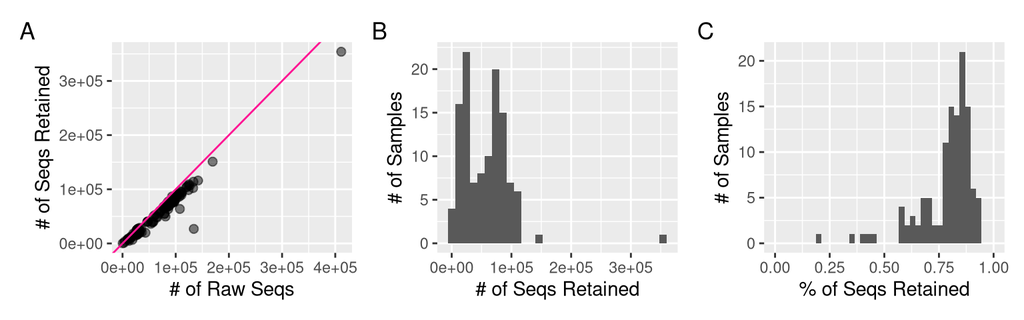

```r
# Plot it
numSeqs_QC_dotplot <-
  filtered_df %>%
  ggplot(aes(x = reads.in, y = reads.out)) +
  geom_point(alpha = 0.5, size = 2) +
  labs(x = "# of Raw Seqs",
       y = "# of Seqs Retained") +
  # Now let's add a 1:1 line for reference of keeping 100% of the reads
  geom_abline(slope=1, intercept = 0, color = "deeppink")

# Now, let's look at the number of reads retained in a histogram
numRetained_QC_histplot <-
  filtered_df %>%
  ggplot(aes(x = reads.out)) +
  geom_histogram() +
  labs(x = "# of Seqs Retained",
       y = "# of Samples")

# Create a histogram of percent reads retained in a histogram
percSeqs_QC_histplot <-
  filtered_df %>%
  ggplot(aes(x = percent.retained)) +
  geom_histogram() +
  labs(x = "% of Seqs Retained",
       y = "# of Samples") +
  # Set the scale to be between 0-1 (0-100%)
  coord_cartesian(xlim = c(0, 1))

# Now, let's put the plots together
numSeqs_QC_dotplot + numRetained_QC_histplot + percSeqs_QC_histplot +
  plot_annotation(tag_levels = 'A')
```

## B. Visualize QC differences Pre- and Post-Filtering & Trimming

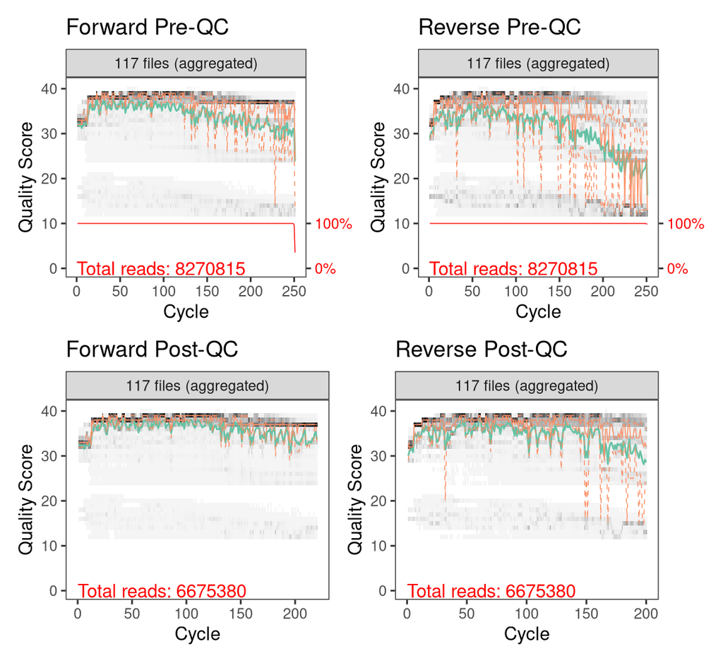

```r
# Plot the pre and post together in one plot
preQC_aggregate_plot / postQC_aggregate_plot
```

INTERPRETATION #5 is comparing your pre-QC to your post-QC read quality. Here, in this location of your analyses, please insert a description of the interpretation you draw from yor overall quality control results. Are you satisfied with your QC process? An example interpretation is provided below.

Forward Reads (Pre vs. Post-QC): Beginning of read: No trimming was applied to the start of the forward reads, as initial base quality was already high (above Q30), and this is reflected in the post-QC plot where early-cycle quality remains strong. Middle of read: Quality remains consistently high (~Q30–Q40) across most of the read, indicating that the majority of bases are reliable. End of read: An extremely slight decline in quality is still present toward the end of the read, but it is minimal and remains within acceptable levels, showing that significant trimming was not needed. This is still expected of Illumina sequencing, and to preserve read lengths, this is more than acceptable.

Reverse Reads (Pre vs. Post-QC): Beginning of read: No trimming was applied at the start, and quality remains acceptable in the early cycles. Middle of read: Mid-read quality (~10–170 bp) remains strong and stable after filtering. End of read: The trailing end of the reverse reads still shows some decline in quality after ~170–200 cycles, but this drop is less severe than in the pre-QC data. The lowest-quality bases have been removed, and the remaining decline is expected for Illumina sequencing. The drop in quality in the post-QC reverse reads is significantly less than in the pre-QC, showing that despite prioritizing read lengths over only quality, the data is still quite good and usable.

# Check Render Time

```r
# Take the time now that we are at the end of the script
end_time <- Sys.time()
end_time
```

```
## [1] "2026-03-19 21:51:32 EDT"
```

```r
# Echo the elapsed time
elapsed_time <- round((end_time - start_time), 3)
elapsed_time
```

```
## Time difference of 29.376 mins
```